# Applied Predictive Modelling C1

Tuesday, May 26, 2015

```r
library(AppliedPredictiveModeling); library(caret); library(corrplot); library(e1071); library(lattice); library(dplyr)
```

## Computing

### Selection

```r
# apropos() function will search any loaded R function for given term
apropos('confusion')
```

```
## [1] "confusionMatrix"       "confusionMatrix.train"
```

```r
# to find function in any packahe, RSiteSearch() is handy

#RSiteSearch('confusion', restrict = 'functions')
```

The segemenatation data nice example set- lets play with subsetting

```r
data(segmentationOriginal)

# data already split into train and test
segData <- filter(segmentationOriginal, Case == 'Train')
```

The Class and Cell fields can be saved into seperate vectors, then removed from the main object

```r
cellID <- segData$Cell
class <- segData$Class
case <- segData$Case
# remove columns
segData <- segData[, -(1:3)]
```

Want to remove column names with ‘Status’, as these are binary versions of predictors

```r
statusColNum <- grep('Status', names(segData))
segData <- segData[, -statusColNum]
```

### Transformation

Some of the data are significantly skewed

```r
skewness(segData$AngleCh1)
```

```
## [1] -0.02426252
```

```r
# Can apply skewness over all columns
skewValues <- apply(segData, 2, skewness)
head(skewValues)
```

```
##    AngleCh1     AreaCh1 AvgIntenCh1 AvgIntenCh2 AvgIntenCh3 AvgIntenCh4
## -0.02426252  3.52510745  2.95918524  0.84816033  2.20234214  1.90047128
```

Can use this as first hint- investigate skewbed predictors further.

MASS package contains boxcox() function. This function estimates ( ) lambda. Use caret function BoxCoxTrans() to apply the transformation.

```r
Ch1AreaTrans <- BoxCoxTrans(segData$AreaCh1)
Ch1AreaTrans
```

```
## Box-Cox Transformation
##
## 1009 data points used to estimate Lambda
##
## Input data summary:
##    Min. 1st Qu.  Median    Mean 3rd Qu.    Max.
##   150.0   194.0   256.0   325.1   376.0  2186.0
##
## Largest/Smallest: 14.6
## Sample Skewness: 3.53
##
## Estimated Lambda: -0.9
```

```r
#origional data
head(segData$AreaCh1)
```

```
## [1] 819 431 298 256 258 358
```

```r
#after transform
predict(Ch1AreaTrans, head(segData$AreaCh1))
```

```
## [1] 1.108458 1.106383 1.104520 1.103554 1.103607 1.105523
```

The caret function preProcess() applies transformations to set of predictors. This can include a bunch or preprocessings (see example in a bit)

prcomp() function in base R:

```r
pcaObject <- prcomp(segData, center=TRUE, scale. = TRUE)
#calculate percentage variance of components
percentVariance <- pcaObject$sd^2 / sum(pcaObject$sd^2) * 100
percentVariance[1:3]
```

```
## [1] 20.91236 17.01330 11.88689
```

Transformed values are stored in pcaObject as sub-object x:

```r
head(pcaObject$x[, 1:5])
```

```
##             PC1        PC2         PC3       PC4        PC5
## [1,]  5.0985749  4.5513804 -0.03345155 -2.640339  1.2783212
## [2,] -0.2546261  1.1980326 -1.02059569 -3.731079  0.9994635
## [3,]  1.2928941 -1.8639348 -1.25110461 -2.414857 -1.4914838
## [4,] -1.4646613 -1.5658327  0.46962088 -3.388716 -0.3302324
## [5,] -0.8762771 -1.2790055 -1.33794261 -3.516794  0.3936099
## [6,] -0.8615416 -0.3286842 -0.15546723 -2.206636  1.4731658
```

The sub-object rotation stores the variable loadings

```r
head(pcaObject$rotation[, 1:3])
```

```
##                      PC1         PC2          PC3
## AngleCh1     0.001213758 -0.01284461  0.006816473
## AreaCh1      0.229171873  0.16061734  0.089811727
## AvgIntenCh1 -0.102708778  0.17971332  0.067696745
## AvgIntenCh2 -0.154828672  0.16376018  0.073534399
## AvgIntenCh3 -0.058042158  0.11197704 -0.185473286
## AvgIntenCh4 -0.117343465  0.21039086 -0.105060977
```

For spatial sign transforms REMEMBER to center and scale first. Spatial sign for models which are sensitive to outliers

```r
#spatObject <- spatialSign(segData)
```

The segData does not have any missing values, but for data with these can use impute package with knn imputation impute.knn()

The preProcess() function in caret is handy to apply all the preprocessing

```r
trans <- preProcess(segData,
                 method = c("BoxCox", "center", "scale", "pca"))
trans
```

```
##
## Call:
## preProcess.default(x = segData, method = c("BoxCox", "center",
##  "scale", "pca"))
##
## Created from 1009 samples and 58 variables
## Pre-processing: Box-Cox transformation, centered, scaled,
##  principal component signal extraction
##
## Lambda estimates for Box-Cox transformation:
##     Min.  1st Qu.   Median     Mean  3rd Qu.     Max.     NA's
## -2.00000 -0.50000 -0.10000  0.05106  0.30000  2.00000       11
##
## PCA needed 19 components to capture 95 percent of the variance
```

```r
#apply transformations
tranformed <- predict(trans, segData)
```

The order of preprocessing is center, scale, inputation, feature extraction then spatial sign.

### Filtering

Use nearZeroVar() to find predictors with near zero variance

```r
nearZeroVar(segData)
```

```
## integer(0)
```

For correlations use cor()

```r
correlation <- cor(segData)
correlation[1:4, 1:4]
```

```
##                 AngleCh1      AreaCh1 AvgIntenCh1 AvgIntenCh2
## AngleCh1     1.000000000 -0.002627172 -0.04300776 -0.01944681
## AreaCh1     -0.002627172  1.000000000 -0.02529739 -0.15330301
## AvgIntenCh1 -0.043007757 -0.025297394  1.00000000  0.52521711
## AvgIntenCh2 -0.019446810 -0.153303007  0.52521711  1.00000000
```

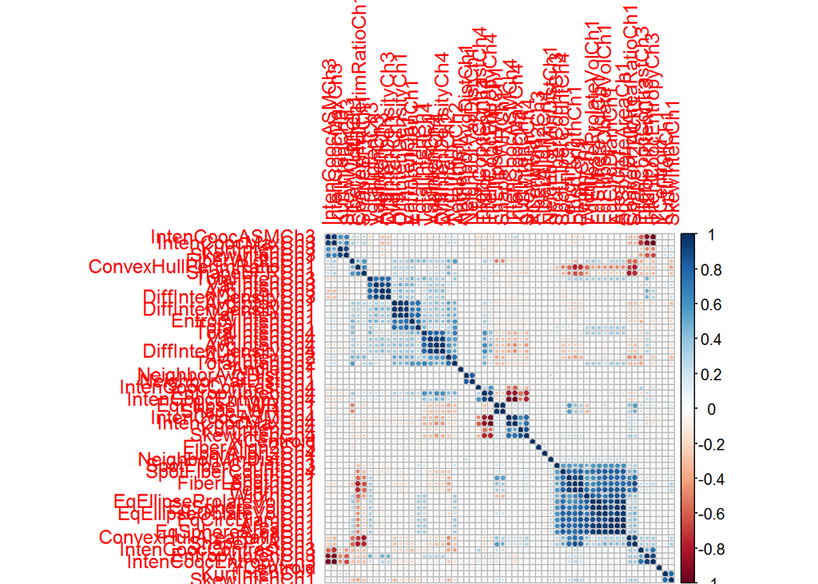

```r
corrplot(correlation, order = "hclust")
```

To filter based on correlations, use findCorrelation()

```r
highCorr <- findCorrelation(correlation, cutoff = .75)
filteredSegData <- segData[, -highCorr]
```

### Dummies

Use dummies for tree based models- makes splits more interpretable!!

```r
library(caret)
data(cars)
#seems cars are already in dummy form
#carSub <- select(cars, Price, Mileage, Type)
#head(cars)
#levels(carSub$Type)

#simpleMod <- dummyVars(~Mileage + Type,
#                       data = carSubset,
#                       levelsOnly = TRUE)

# makes Type a dummy now
# USE predict() method on dataset in conjunction with dummyVars

#predict(simpleMod, head(carSubset))

#if you want an interaction term, use :

#withInteraction <- dummyVars(~Mileage + Type + Mileage:Type,
#                    data = carSubset, levelsOnly = TRUE)
```

## Excercises

```r
library(mlbench)
data(Glass)
str(Glass)
```

```
## 'data.frame':    214 obs. of  10 variables:
##  $ RI  : num  1.52 1.52 1.52 1.52 1.52 ...
##  $ Na  : num  13.6 13.9 13.5 13.2 13.3 ...
##  $ Mg  : num  4.49 3.6 3.55 3.69 3.62 3.61 3.6 3.61 3.58 3.6 ...
##  $ Al  : num  1.1 1.36 1.54 1.29 1.24 1.62 1.14 1.05 1.37 1.36 ...
##  $ Si  : num  71.8 72.7 73 72.6 73.1 ...
##  $ K   : num  0.06 0.48 0.39 0.57 0.55 0.64 0.58 0.57 0.56 0.57 ...
##  $ Ca  : num  8.75 7.83 7.78 8.22 8.07 8.07 8.17 8.24 8.3 8.4 ...
##  $ Ba  : num  0 0 0 0 0 0 0 0 0 0 ...
##  $ Fe  : num  0 0 0 0 0 0.26 0 0 0 0.11 ...
##  $ Type: Factor w/ 6 levels "1","2","3","5",..: 1 1 1 1 1 1 1 1 1 1 ...
```